# Chapter 5

# 5.1 Spurious association

```r
# laod data
library(rethinking)
data("WaffleDivorce")
d <- WaffleDivorce

# standardise predictor
d$MedianAgeMarriage.s <- (d$MedianAgeMarriage -
                            mean(d$MedianAgeMarriage))/
  sd(d$MedianAgeMarriage)

# fit model
m5.1 <- map(
  alist(
    Divorce ~ dnorm(mu, sigma),
    mu <- a + bA * MedianAgeMarriage.s,
    a ~ dnorm(10, 10),
    bA ~ dnorm(0, 1),
    sigma ~ dunif(0, 10)
  ),
  data = d
)

precis(m5.1)
```

|  | Mean | StdDev | 5.5% | 94.5% |
| --- | --- | --- | --- | --- |
| a | 9.69 | 0.20 | 9.36 | 10.01 |
| bA | -1.04 | 0.20 | -1.37 | -0.72 |
| sigma | 1.45 | 0.14 | 1.22 | 1.68 |

```r
# compute percentile interval of mean
MAM.seq <- seq( from = -3, to = 3.5, length.out = 30)
mu <- link(m5.1, data = data.frame(MedianAgeMarriage.s = MAM.seq))
```

```
[ 100 / 1000 ]
[ 200 / 1000 ]
[ 300 / 1000 ]
[ 400 / 1000 ]
[ 500 / 1000 ]
[ 600 / 1000 ]
[ 700 / 1000 ]
[ 800 / 1000 ]
[ 900 / 1000 ]
[ 1000 / 1000 ]
```

```r
mu.PI <- apply(mu, 2, PI)

# plot it all
plot(Divorce ~ MedianAgeMarriage.s, data = d, col=rangi2)
abline(m5.1)
```

```
only using the first two of 3 regression coefficients
```

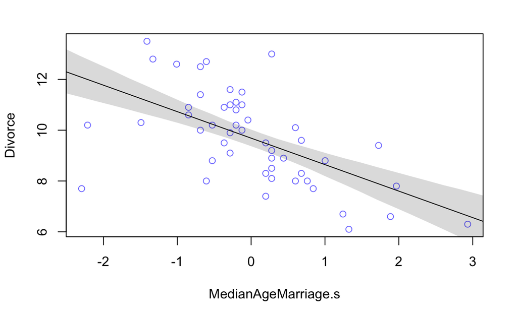

```r
shade(mu.PI, MAM.seq)
```

```r
d$Marriage.s <- (d$Marriage - mean(d$Marriage))/sd(d$Marriage)
m5.2 <- map(
  alist(
    Divorce ~ dnorm(mu, sigma),
    mu <- a + bR * Marriage.s,
    a ~ dnorm(10, 10),
    bR ~ dnorm(0, 1),
    sigma ~ dunif(0, 10)
  ), data = d
)

precis(m5.2)
```

|  | Mean | StdDev | 5.5% | 94.5% |
| --- | --- | --- | --- | --- |
| a | 9.69 | 0.24 | 9.31 | 10.07 |
| bR | 0.64 | 0.23 | 0.27 | 1.02 |
| sigma | 1.67 | 0.17 | 1.40 | 1.94 |

## 5.1.1 Multivariate notation

## 5.1.2 Fitting the model

```r
m5.3 <- map(
    alist(
        Divorce ~ dnorm( mu , sigma ) ,
        mu <- a + bR*Marriage.s + bA*MedianAgeMarriage.s ,
        a ~ dnorm( 10 , 10 ) ,
        bR ~ dnorm( 0 , 1 ) ,
        bA ~ dnorm( 0 , 1 ) ,
        sigma ~ dunif( 0 , 10 )
    ) ,
    data = d )
precis( m5.3 )
```

|  | Mean | StdDev | 5.5% | 94.5% |
| --- | --- | --- | --- | --- |
| a | 9.69 | 0.20 | 9.36 | 10.01 |
| bR | -0.13 | 0.28 | -0.58 | 0.31 |
| bA | -1.13 | 0.28 | -1.58 | -0.69 |
| sigma | 1.44 | 0.14 | 1.21 | 1.67 |

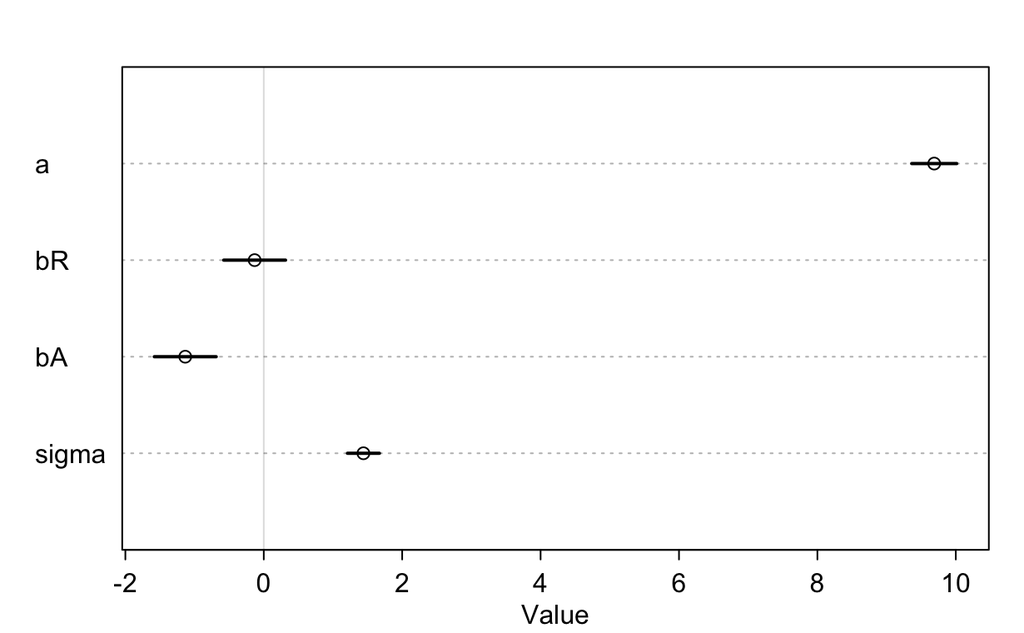

```r
plot(precis(m5.3))
```

## 5.1.3 Plotting multivariate posteriors

### 5.1.3.1 *Predictor residual plots*

```r
m5.4 <- map(
    alist(
        Marriage.s ~ dnorm( mu , sigma ) ,
        mu <- a + b*MedianAgeMarriage.s ,
        a ~ dnorm( 0 , 10 ) ,
        b ~ dnorm( 0 , 1 ) ,
        sigma ~ dunif( 0 , 10 )
    ) ,
    data = d )
```

```r
# compute expected value at MAP, for each State
mu <- coef(m5.4)['a'] + coef(m5.4)['b']*d$MedianAgeMarriage.s
# compute residual for each State
m.resid <- d$Marriage.s - mu
```

```r
plot( Marriage.s ~ MedianAgeMarriage.s , d , col=rangi2 )
abline( m5.4 )
```

```
only using the first two of 3 regression coefficients
```

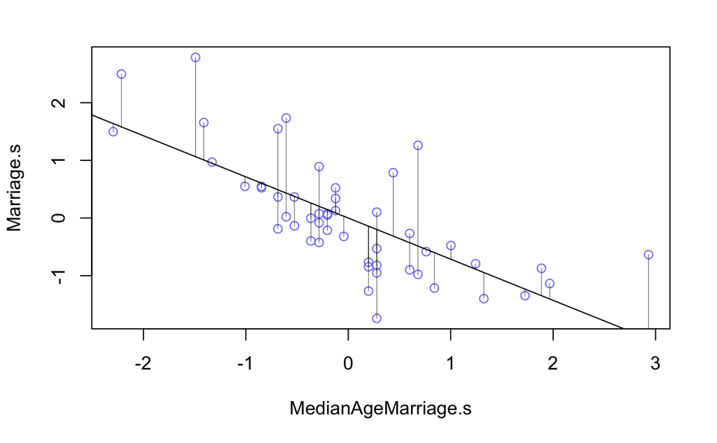

```r
# loop over States
for ( i in 1:length(m.resid) ) {
    x <- d$MedianAgeMarriage.s[i] # x location of line segment
    y <- d$Marriage.s[i] # observed endpoint of line segment
    # draw the line segment
    lines( c(x,x) , c(mu[i],y) , lwd=0.5 , col=col.alpha("black",0.7) )
}
```

### 5.1.3.2 Counterfactual plots

```r
# prepare new counterfactual data
A.avg <- mean( d$MedianAgeMarriage.s )
R.seq <- seq( from=-3 , to=3 , length.out=30 )
pred.data <- data.frame(
    Marriage.s=R.seq,
    MedianAgeMarriage.s=A.avg
)

# compute counterfactual mean divorce (mu)
mu <- link( m5.3 , data=pred.data )
```

```
[ 100 / 1000 ]
[ 200 / 1000 ]
[ 300 / 1000 ]
[ 400 / 1000 ]
[ 500 / 1000 ]
[ 600 / 1000 ]
[ 700 / 1000 ]
[ 800 / 1000 ]
[ 900 / 1000 ]
[ 1000 / 1000 ]
```

```r
mu.mean <- apply( mu , 2 , mean )
mu.PI <- apply( mu , 2 , PI )

# simulate counterfactual divorce outcomes
R.sim <- sim( m5.3 , data=pred.data , n=1e4 )
```

```
[ 1000 / 10000 ]
[ 2000 / 10000 ]
[ 3000 / 10000 ]
[ 4000 / 10000 ]
[ 5000 / 10000 ]
[ 6000 / 10000 ]
[ 7000 / 10000 ]
[ 8000 / 10000 ]
[ 9000 / 10000 ]
[ 10000 / 10000 ]
```

```r
R.PI <- apply( R.sim , 2 , PI )

# display predictions, hiding raw data with type="n"
plot( Divorce ~ Marriage.s , data=d , type="n" )
mtext( "MedianAgeMarriage.s = 0" )
```

```r
lines( R.seq , mu.mean )
shade( mu.PI , R.seq )
```

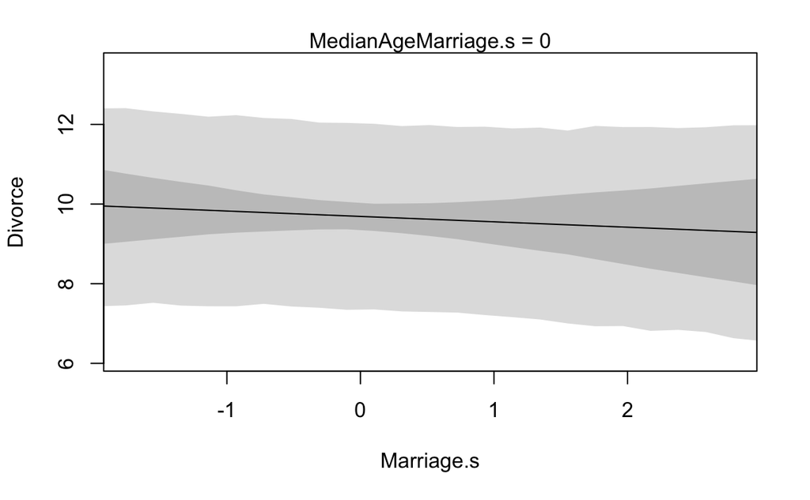

```r
shade( R.PI , R.seq )
```

```r
R.avg <- mean( d$Marriage.s )
A.seq <- seq( from=-3 , to=3.5 , length.out=30 )
pred.data2 <- data.frame(
    Marriage.s=R.avg,
    MedianAgeMarriage.s=A.seq
)

mu <- link( m5.3 , data=pred.data2 )
```

```
[ 100 / 1000 ]
[ 200 / 1000 ]
[ 300 / 1000 ]
[ 400 / 1000 ]
[ 500 / 1000 ]
[ 600 / 1000 ]
[ 700 / 1000 ]
[ 800 / 1000 ]
[ 900 / 1000 ]
[ 1000 / 1000 ]
```

```r
mu.mean <- apply( mu , 2 , mean )
mu.PI <- apply( mu , 2 , PI )

A.sim <- sim( m5.3 , data=pred.data2 , n=1e4 )
```

```
[ 1000 / 10000 ]
[ 2000 / 10000 ]
[ 3000 / 10000 ]
[ 4000 / 10000 ]
[ 5000 / 10000 ]
[ 6000 / 10000 ]
[ 7000 / 10000 ]
[ 8000 / 10000 ]
[ 9000 / 10000 ]
[ 10000 / 10000 ]
```

```r
A.PI <- apply( A.sim , 2 , PI )

plot( Divorce ~ MedianAgeMarriage.s , data=d , type="n" )
mtext( "Marriage.s = 0" )
```

```r
lines( A.seq , mu.mean )
shade( mu.PI , A.seq )
```

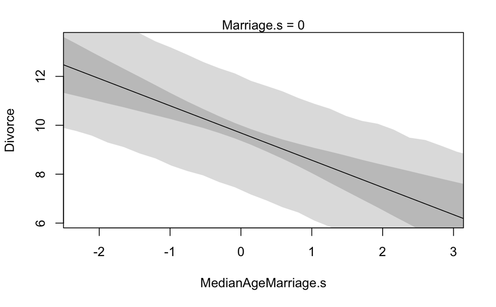

```r
shade( A.PI , A.seq )
```

```r
# call link without specifying new data
# so it uses original data
mu <- link( m5.3 )
```

```
[ 100 / 1000 ]
[ 200 / 1000 ]
[ 300 / 1000 ]
[ 400 / 1000 ]
[ 500 / 1000 ]
[ 600 / 1000 ]
[ 700 / 1000 ]
[ 800 / 1000 ]
[ 900 / 1000 ]
[ 1000 / 1000 ]
```

```r
# summarize samples across cases
mu.mean <- apply( mu , 2 , mean )
mu.PI <- apply( mu , 2 , PI )

# simulate observations
# again no new data, so uses original data
divorce.sim <- sim( m5.3 , n=1e4 )
```

```
[ 1000 / 10000 ]
[ 2000 / 10000 ]
[ 3000 / 10000 ]
[ 4000 / 10000 ]
[ 5000 / 10000 ]
[ 6000 / 10000 ]
[ 7000 / 10000 ]
[ 8000 / 10000 ]
[ 9000 / 10000 ]
[ 10000 / 10000 ]
```

```r
divorce.PI <- apply( divorce.sim , 2 , PI )
```

```r
plot( mu.mean ~ d$Divorce , col=rangi2 , ylim=range(mu.PI) ,
    xlab="Observed divorce" , ylab="Predicted divorce" )
abline( a=0 , b=1 , lty=2 )
```

```
integer(0)
```

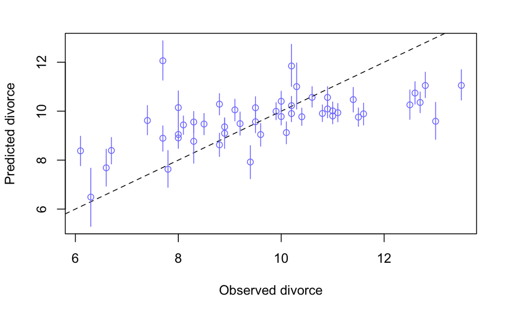

```r
for ( i in 1:nrow(d) )
    lines( rep(d$Divorce[i],2) , c(mu.PI[1,i],mu.PI[2,i]) ,
        col=rangi2 )
identify( x=d$Divorce , y=mu.mean , labels=d$Loc , cex=0.8 )
```

```r
# compute residuals
divorce.resid <- d$Divorce - mu.mean
# get ordering by divorce rate
o <- order(divorce.resid)
# make the plot
dotchart( divorce.resid[o] , labels=d$Loc[o] , xlim=c(-6,5) , cex=0.6 )
abline( v=0 , col=col.alpha("black",0.2) )
```

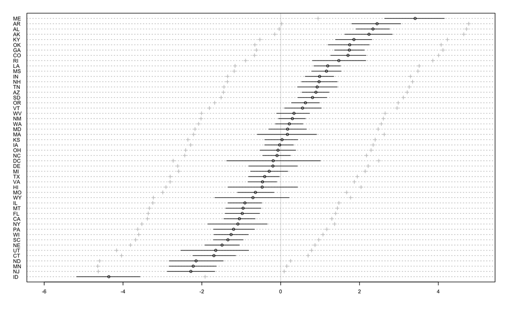

```r
for ( i in 1:nrow(d) ) {
    j <- o[i] # which State in order
    lines( d$Divorce[j]-c(mu.PI[1,j],mu.PI[2,j]) , rep(i,2) )
    points( d$Divorce[j]-c(divorce.PI[1,j],divorce.PI[2,j]) , rep(i,2),
        pch=3 , cex=0.6 , col="gray" )
}
```

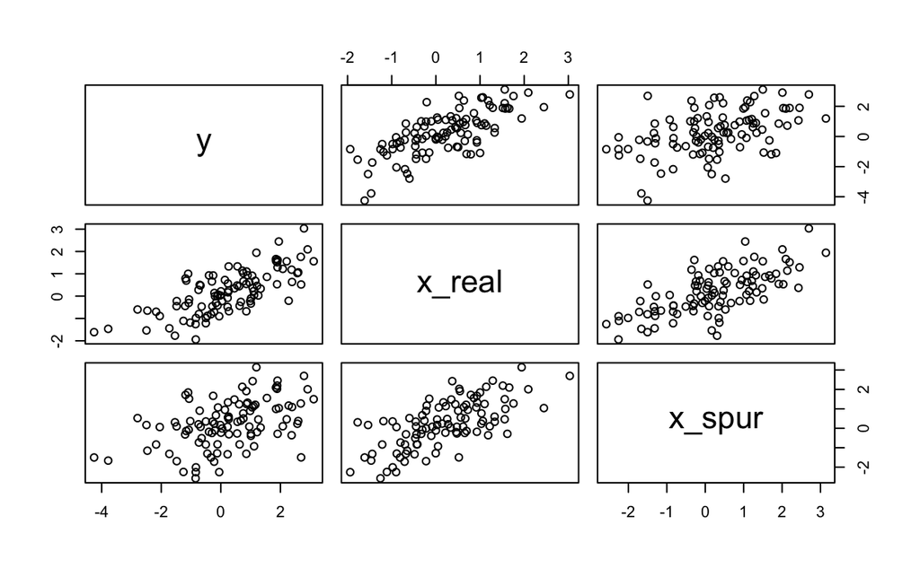

```r
N <- 100                         # number of cases
x_real <- rnorm( N )             # x_real as Gaussian with mean 0 and stddev 1
x_spur <- rnorm( N , x_real )    # x_spur as Gaussian with mean=x_real
y <- rnorm( N , x_real )         # y as Gaussian with mean=x_real
d <- data.frame(y,x_real,x_spur) # bind all together in data frame
pairs(d)
```

```r
mtest <- map(
  alist(
    y ~ dnorm(mu, sigma),
    mu <-  a + b1 * x_real + b2 * x_spur,
    a ~ dnorm(10, 10),
    b1 ~ dnorm(0, 1),
    b2 ~ dnorm(0, 1),
    sigma ~ dunif(0, 10)
  ),
  data = d
)
precis(mtest)
```

|  | Mean | StdDev | 5.5% | 94.5% |
| --- | --- | --- | --- | --- |
| a | 0.04 | 0.10 | -0.12 | 0.21 |
| b1 | 1.12 | 0.14 | 0.90 | 1.35 |
| b2 | -0.07 | 0.11 | -0.24 | 0.11 |
| sigma | 1.00 | 0.07 | 0.89 | 1.11 |

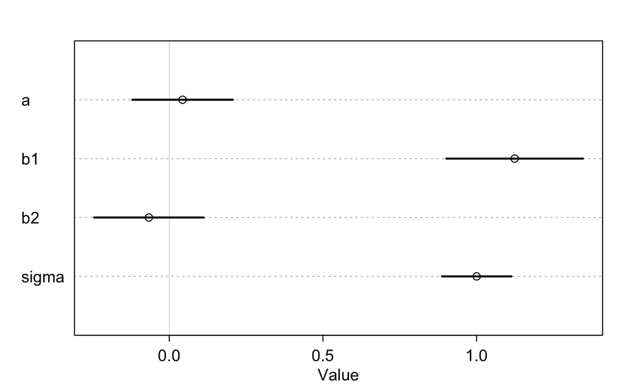

```r
plot(precis(mtest))
```

# 5.2 Masked relationships

```r
library(rethinking)
data(milk)
d <- milk
str(d)
```

```
'data.frame':   29 obs. of  8 variables:
 $ clade         : Factor w/ 4 levels "Ape","New World Monkey",..: 4 4 4 4 4 2 2 2 2 2 ...
 $ species       : Factor w/ 29 levels "A palliata","Alouatta seniculus",..: 11 8 9 10 16 2 1 6 28 27 ...
 $ kcal.per.g    : num  0.49 0.51 0.46 0.48 0.6 0.47 0.56 0.89 0.91 0.92 ...
 $ perc.fat      : num  16.6 19.3 14.1 14.9 27.3 ...
 $ perc.protein  : num  15.4 16.9 16.9 13.2 19.5 ...
 $ perc.lactose  : num  68 63.8 69 71.9 53.2 ...
 $ mass          : num  1.95 2.09 2.51 1.62 2.19 5.25 5.37 2.51 0.71 0.68 ...
 $ neocortex.perc: num  55.2 NA NA NA NA ...
```

```r
m5.5 <- map(
    alist(
        kcal.per.g ~ dnorm( mu , sigma ) ,
        mu <- a + bn*neocortex.perc ,
        a ~ dnorm( 0 , 100 ) ,
        bn ~ dnorm( 0 , 1 ) ,
        sigma ~ dunif( 0 , 1 )
    ) ,
    data=d )
```

```r
d$neocortex.perc
```

```
 [1] 55.16    NA    NA    NA    NA 64.54 64.54 67.64    NA 68.85 58.85 61.69 60.32
[14]    NA    NA 69.97    NA 70.41    NA 73.40    NA 67.53    NA 71.26 72.60    NA
[27] 70.24 76.30 75.49
```

```r
dcc <- d[complete.cases(d), ]
```

```r
m5.5 <- map(
    alist(
        kcal.per.g ~ dnorm( mu , sigma ) ,
        mu <- a + bn*neocortex.perc ,
        a ~ dnorm( 0 , 100 ) ,
        bn ~ dnorm( 0 , 1 ) ,
        sigma ~ dunif( 0 , 1 )
    ) ,
    data=dcc )

precis(m5.5, digits = 3)
```

|  | Mean | StdDev | 5.5% | 94.5% |
| --- | --- | --- | --- | --- |
| a | 0.353 | 0.471 | -0.399 | 1.106 |
| bn | 0.005 | 0.007 | -0.007 | 0.016 |
| sigma | 0.166 | 0.028 | 0.120 | 0.211 |

```r
np.seq <- 0:100
pred.data <- data.frame( neocortex.perc=np.seq )

mu <- link( m5.5 , data=pred.data , n=1e4 )
```

```
[ 1000 / 10000 ]
[ 2000 / 10000 ]
[ 3000 / 10000 ]
[ 4000 / 10000 ]
[ 5000 / 10000 ]
[ 6000 / 10000 ]
[ 7000 / 10000 ]
[ 8000 / 10000 ]
[ 9000 / 10000 ]
[ 10000 / 10000 ]
```

```r
mu.mean <- apply( mu , 2 , mean )
mu.PI <- apply( mu , 2 , PI )

plot( kcal.per.g ~ neocortex.perc , data=dcc , col=rangi2 )
lines( np.seq , mu.mean )
```

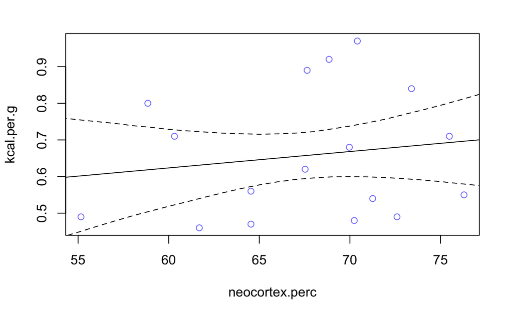

```r
lines( np.seq , mu.PI[1,] , lty=2 )
lines( np.seq , mu.PI[2,] , lty=2 )
```

```r
dcc$log.mass <- log(dcc$mass)
```

```r
m5.6 <- map(
    alist(
        kcal.per.g ~ dnorm( mu , sigma ) ,
        mu <- a + bm*log.mass ,
        a ~ dnorm( 0 , 100 ) ,
        bm ~ dnorm( 0 , 1 ) ,
        sigma ~ dunif( 0 , 1 )
    ) ,
    data=dcc )
precis(m5.6)
```

|  | Mean | StdDev | 5.5% | 94.5% |
| --- | --- | --- | --- | --- |
| a | 0.71 | 0.05 | 0.63 | 0.78 |
| bm | -0.03 | 0.02 | -0.06 | 0.00 |
| sigma | 0.16 | 0.03 | 0.11 | 0.20 |

```r
mass.seq <- seq(from = min(dcc$mass),
                to = 100,
                length.out = 1e3)
pred.data <- data.frame( log.mass=log(mass.seq ))

mu <- link( m5.6 , data=pred.data , n=1e4 )
```

```
[ 1000 / 10000 ]
[ 2000 / 10000 ]
[ 3000 / 10000 ]
[ 4000 / 10000 ]
[ 5000 / 10000 ]
[ 6000 / 10000 ]
[ 7000 / 10000 ]
[ 8000 / 10000 ]
[ 9000 / 10000 ]
[ 10000 / 10000 ]
```

```r
mu.mean <- apply( mu , 2 , mean )
mu.PI <- apply( mu , 2 , PI )

plot( kcal.per.g ~ log.mass , data=dcc , col=rangi2 )
lines( log(mass.seq) , mu.mean )
```

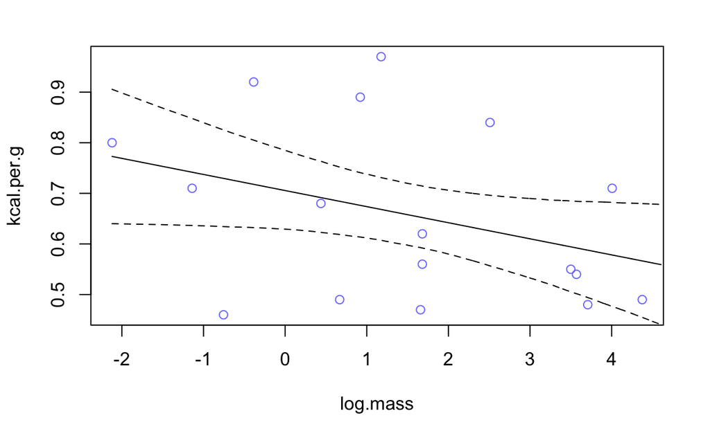

```r
lines( log(mass.seq) , mu.PI[1,] , lty=2 )
lines( log(mass.seq) , mu.PI[2,] , lty=2 )
```

```r
m5.7 <- map(
    alist(
        kcal.per.g ~ dnorm( mu , sigma ) ,
        mu <- a + bn*neocortex.perc + bm*log.mass ,
        a ~ dnorm( 0 , 100 ) ,
        bn ~ dnorm( 0 , 1 ) ,
        bm ~ dnorm( 0 , 1 ) ,
        sigma ~ dunif( 0 , 1 )
    ) ,
    data=dcc )
precis(m5.7)
```

|  | Mean | StdDev | 5.5% | 94.5% |
| --- | --- | --- | --- | --- |
| a | -1.08 | 0.47 | -1.83 | -0.34 |
| bn | 0.03 | 0.01 | 0.02 | 0.04 |
| bm | -0.10 | 0.02 | -0.13 | -0.06 |
| sigma | 0.11 | 0.02 | 0.08 | 0.15 |

```r
NA
```

```r
mean.log.mass <- mean( log(dcc$mass) )
np.seq <- 0:100
pred.data <- data.frame(
    neocortex.perc=np.seq,
    log.mass=mean.log.mass
)

mu <- link( m5.7 , data=pred.data , n=1e4 )
```

```
[ 1000 / 10000 ]
[ 2000 / 10000 ]
[ 3000 / 10000 ]
[ 4000 / 10000 ]
[ 5000 / 10000 ]
[ 6000 / 10000 ]
[ 7000 / 10000 ]
[ 8000 / 10000 ]
[ 9000 / 10000 ]
[ 10000 / 10000 ]
```

```r
mu.mean <- apply( mu , 2 , mean )
mu.PI <- apply( mu , 2 , PI )

plot( kcal.per.g ~ neocortex.perc , data=dcc , type="n" )
lines( np.seq , mu.mean )
```

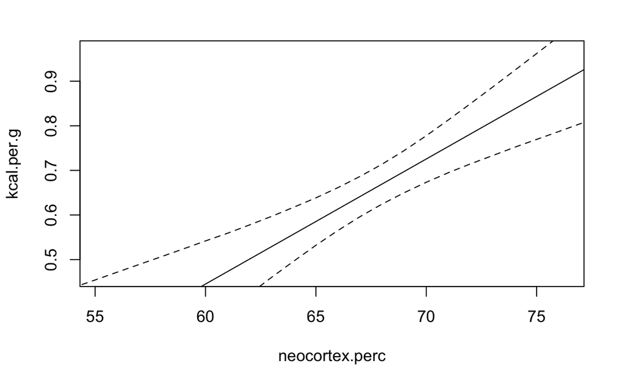

```r
lines( np.seq , mu.PI[1,] , lty=2 )
lines( np.seq , mu.PI[2,] , lty=2 )
```

```r
mean.np <- mean( dcc$neocortex.perc )
mass.seq <- seq(from = min(dcc$mass),
                to = 100,
                length.out = 1e3)
pred.data <- data.frame(
    neocortex.perc=mean.np,
    log.mass= log(mass.seq)
)

mu <- link( m5.7 , data=pred.data , n=1e4 )
```

```
[ 1000 / 10000 ]
[ 2000 / 10000 ]
[ 3000 / 10000 ]
[ 4000 / 10000 ]
[ 5000 / 10000 ]
[ 6000 / 10000 ]
[ 7000 / 10000 ]
[ 8000 / 10000 ]
[ 9000 / 10000 ]
[ 10000 / 10000 ]
```

```r
mu.mean <- apply( mu , 2 , mean )
mu.PI <- apply( mu , 2 , PI )

plot( kcal.per.g ~ log.mass , data=dcc , type="n" )
lines( log(mass.seq) , mu.mean )
```

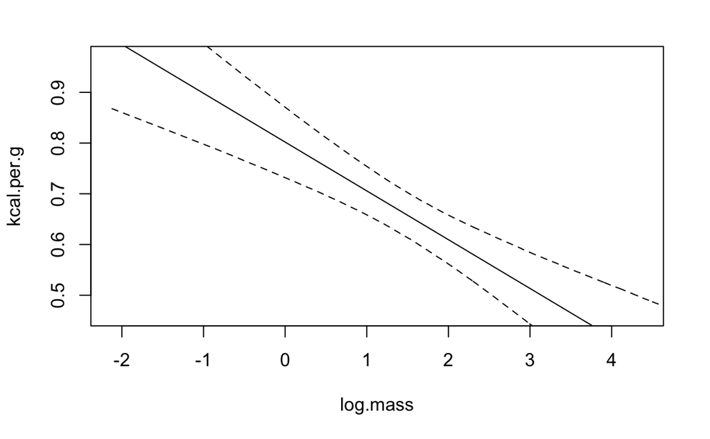

```r
lines( log(mass.seq) , mu.PI[1,] , lty=2 )
lines( log(mass.seq) , mu.PI[2,] , lty=2 )
```

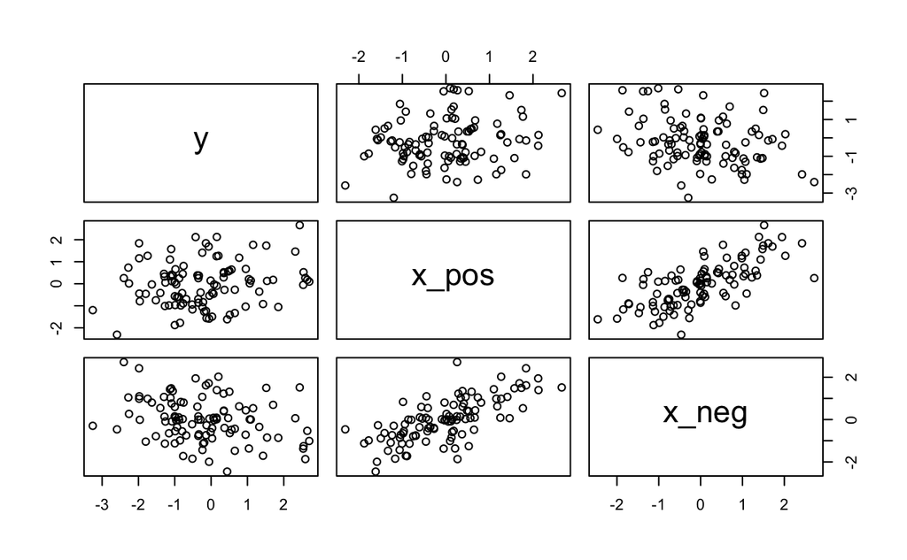

```r
N <- 100                         # number of cases
rho <- 0.7                       # correlation btw x_pos and x_neg
x_pos <- rnorm( N )              # x_pos as Gaussian
x_neg <- rnorm( N , rho*x_pos ,  # x_neg correlated with x_pos
    sqrt(1-rho^2) )
y <- rnorm( N , x_pos - x_neg )  # y equally associated with x_pos, x_neg
d <- data.frame(y,x_pos,x_neg)   # bind all together in data frame

pairs(d)
```

# 5.3 When adding variables hurts

## 5.3.1 Multicollinear legs

```r
N <- 100                          # number of individuals
height <- rnorm(N,10,2)           # sim total height of each
leg_prop <- runif(N,0.4,0.5)      # leg as proportion of height
leg_left <- leg_prop*height +     # sim left leg as proportion + error
    rnorm( N , 0 , 0.02 )
leg_right <- leg_prop*height +    # sim right leg as proportion + error
    rnorm( N , 0 , 0.02 )
                                  # combine into data frame
d <- data.frame(height,leg_left,leg_right)
```

```r
# m5.8 <- map(
#     alist(
#         height ~ dnorm( mu , sigma ) ,
#         mu <- a + bl*leg_left + br*leg_right ,
#         a ~ dnorm( 10 , 100 ) ,
#         bl ~ dnorm( 2 , 10 ) ,
#         br ~ dnorm( 2 , 10 ) ,
#         sigma ~ dunif( 0 , 10 )
#     ) ,
#     data=d )
# precis(m5.8)
```

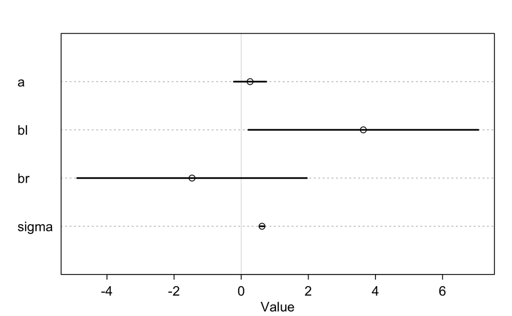

```r
plot(precis(m5.8))
```

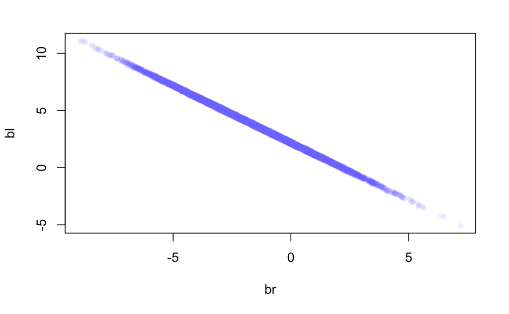

```r
post <- extract.samples(m5.8)
plot(bl ~ br, post, col=col.alpha(rangi2, 0.1), pch = 16)
```

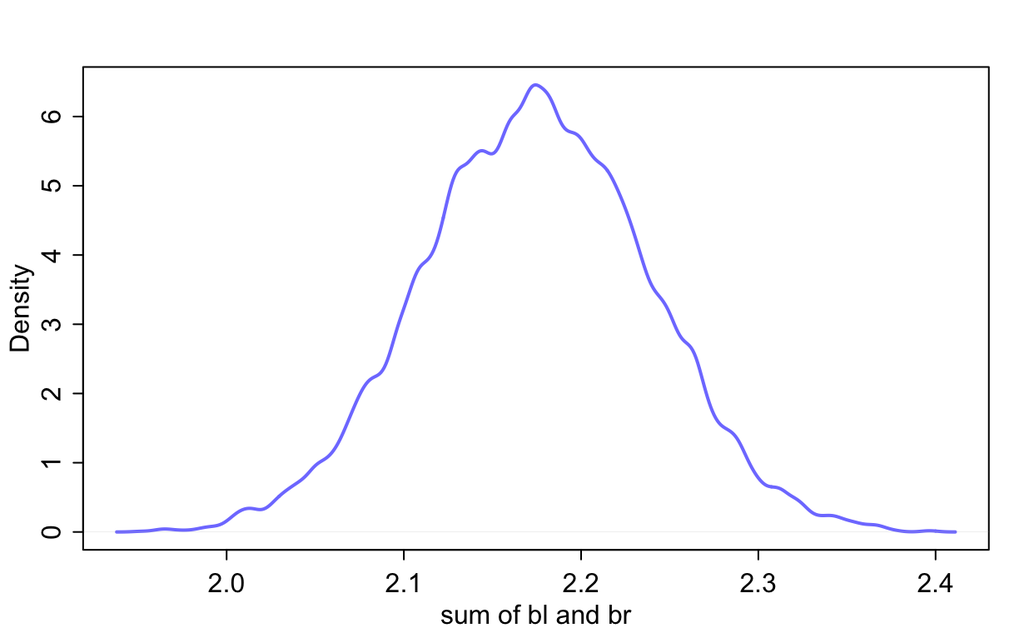

```r
sum_blbr <- post$bl + post$br
dens(sum_blbr, col=rangi2, lwd = 2, xlab="sum of bl and br")
```

```r
m5.9 <- map(
  alist(
    height ~ dnorm(mu, sigma),
    mu <- a + bl*leg_left,
    a ~ dnorm(10, 100),
    bl ~ dnorm(2, 10),
    sigma ~ dunif(0, 10)
  ),
  data = d)
precis(m5.9)
```

|  | Mean | StdDev | 5.5% | 94.5% |
| --- | --- | --- | --- | --- |
| a | 0.96 | 0.33 | 0.42 | 1.49 |
| bl | 2.04 | 0.07 | 1.92 | 2.15 |
| sigma | 0.65 | 0.05 | 0.57 | 0.72 |

## 5.3.2 Multicollinear milk

```r
library(rethinking)
data(milk)
d <- milk
```

```r
# kcal.per.g regressed on perc.fat
m5.10 <- map(
    alist(
        kcal.per.g ~ dnorm( mu , sigma ) ,
        mu <- a + bf*perc.fat ,
        a ~ dnorm( 0.6 , 10 ) ,
        bf ~ dnorm( 0 , 1 ) ,
        sigma ~ dunif( 0 , 10 )
    ) ,
    data=d )

# kcal.per.g regressed on perc.lactose
m5.11 <- map(
    alist(
        kcal.per.g ~ dnorm( mu , sigma ) ,
        mu <- a + bl*perc.lactose ,
        a ~ dnorm( 0.6 , 10 ) ,
        bl ~ dnorm( 0 , 1 ) ,
        sigma ~ dunif( 0 , 10 )
    ) ,
    data=d )

precis( m5.10 , digits=3 )
```

|  | Mean | StdDev | 5.5% | 94.5% |
| --- | --- | --- | --- | --- |
| a | 0.301 | 0.036 | 0.244 | 0.358 |
| bf | 0.010 | 0.001 | 0.008 | 0.012 |
| sigma | 0.073 | 0.010 | 0.058 | 0.089 |

```r
precis( m5.11 , digits=3 )
```

|  | Mean | StdDev | 5.5% | 94.5% |
| --- | --- | --- | --- | --- |
| a | 1.166 | 0.043 | 1.098 | 1.235 |
| bl | -0.011 | 0.001 | -0.012 | -0.009 |
| sigma | 0.062 | 0.008 | 0.049 | 0.075 |

```r
NA
```

```r
m5.12 <- map(
    alist(
        kcal.per.g ~ dnorm( mu , sigma ) ,
        mu <- a + bf*perc.fat + bl*perc.lactose ,
        a ~ dnorm( 0.6 , 10 ) ,
        bf ~ dnorm( 0 , 1 ) ,
        bl ~ dnorm( 0 , 1 ) ,
        sigma ~ dunif( 0 , 10 )
    ) ,
    data=d )
precis( m5.12 , digits=3 )
```

|  | Mean | StdDev | 5.5% | 94.5% |
| --- | --- | --- | --- | --- |
| a | 1.007 | 0.200 | 0.688 | 1.327 |
| bf | 0.002 | 0.002 | -0.002 | 0.006 |
| bl | -0.009 | 0.002 | -0.013 | -0.005 |
| sigma | 0.061 | 0.008 | 0.048 | 0.074 |

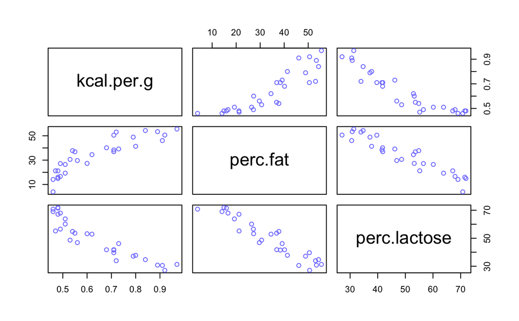

```r
pairs(~ kcal.per.g + perc.fat + perc.lactose,
      data = d, col = rangi2)
```

```r
cor(d$perc.fat, d$perc.lactose)
```

```
[1] -0.9416373
```

## 5.3.3 Post-treatment bias

```r
# number of plants
N <- 100

# simulate initial heights
h0 <- rnorm(N,10,2)

# assign treatments and simulate fungus and growth
treatment <- rep( 0:1 , each=N/2 )
fungus <- rbinom( N , size=1 , prob=0.5 - treatment*0.4 )
h1 <- h0 + rnorm(N, 5 - 3*fungus)

# compose a clean data frame
d <- data.frame( h0=h0 , h1=h1 , treatment=treatment , fungus=fungus )
d
```

| h0 | h1 | treatment | fungus |
| --- | --- | --- | --- |
| 11.826068 | 13.174283 | 0 | 1 |
| 10.376681 | 16.160418 | 0 | 0 |
| 9.902676 | 13.795388 | 0 | 1 |
| 11.615245 | 16.320642 | 0 | 0 |
| 7.667712 | 13.011212 | 0 | 0 |
| 11.358718 | 14.903816 | 0 | 1 |
| 10.211842 | 11.661557 | 0 | 1 |
| 8.086132 | 10.062799 | 0 | 1 |
| 7.426279 | 13.916357 | 0 | 0 |
| 10.437750 | 14.016372 | 0 | 0 |

[output cut: 90 more lines]

```r
m5.13 <- map(
    alist(
        h1 ~ dnorm(mu,sigma),
        mu <- a + bh*h0 + bt*treatment + bf*fungus,
        a ~ dnorm(0,100),
        c(bh,bt,bf) ~ dnorm(0,10),
        sigma ~ dunif(0,10)
    ),
    data=d )
precis(m5.13)
```

|  | Mean | StdDev | 5.5% | 94.5% |
| --- | --- | --- | --- | --- |
| a | 4.18 | 0.53 | 3.34 | 5.03 |
| bh | 1.09 | 0.05 | 1.01 | 1.17 |
| bt | -0.16 | 0.22 | -0.51 | 0.19 |
| bf | -3.02 | 0.26 | -3.44 | -2.60 |
| sigma | 1.00 | 0.07 | 0.89 | 1.11 |

```r
m5.14 <- map(
    alist(
        h1 ~ dnorm(mu,sigma),
        mu <- a + bh*h0 + bt*treatment,
        a ~ dnorm(0,100),
        c(bh,bt) ~ dnorm(0,10),
        sigma ~ dunif(0,10)
    ),
    data=d )
precis(m5.14)
```

|  | Mean | StdDev | 5.5% | 94.5% |
| --- | --- | --- | --- | --- |
| a | 2.30 | 0.77 | 1.07 | 3.53 |
| bh | 1.15 | 0.07 | 1.04 | 1.27 |
| bt | 0.86 | 0.31 | 0.37 | 1.35 |
| sigma | 1.53 | 0.11 | 1.36 | 1.70 |

# 5.4 Cateorical variables

## 5.4.1 Binary categories

```r
data("Howell1")
d <- Howell1
str(d)
```

```
'data.frame':   544 obs. of  4 variables:
 $ height: num  152 140 137 157 145 ...
 $ weight: num  47.8 36.5 31.9 53 41.3 ...
 $ age   : num  63 63 65 41 51 35 32 27 19 54 ...
 $ male  : int  1 0 0 1 0 1 0 1 0 1 ...
```

```r
m5.15 <- map(
  alist(
    height ~ dnorm(mu, sigma),
    mu <- a + bm*male,
    a ~ dnorm(178, 100),
    bm ~ dnorm(0, 10),
    sigma ~ dunif(0, 50)
  ),
  data = d
)
precis(m5.15)
```

|  | Mean | StdDev | 5.5% | 94.5% |
| --- | --- | --- | --- | --- |
| a | 134.83 | 1.59 | 132.29 | 137.37 |
| bm | 7.28 | 2.28 | 3.63 | 10.93 |
| sigma | 27.31 | 0.83 | 25.99 | 28.63 |

```r
post <- extract.samples(m5.15)
mu.male <- post$a + post$bm
PI(mu.male)
```

```
      5%      94%
139.4220 144.8274
```

## 5.4.2 Many categories

```r
data(milk)
d <- milk
unique(d$clade)
```

```
[1] Strepsirrhine    New World Monkey Old World Monkey Ape
Levels: Ape New World Monkey Old World Monkey Strepsirrhine
```

```r
(d$clade.NWM <- ifelse(d$clade == "New World Monkey", 1, 0))
```

```
 [1] 0 0 0 0 0 1 1 1 1 1 1 1 1 1 0 0 0 0 0 0 0 0 0 0 0 0 0 0 0
```

```r
d$clade.OWM <- ifelse(d$clade == "Old World Monkey", 1, 0)
d$clade.S <- ifelse(d$clade == "Strepsirrhine", 1, 0)
```

```r
m5.16 <- map(
    alist(
        kcal.per.g ~ dnorm( mu , sigma ) ,
        mu <- a + b.NWM*clade.NWM + b.OWM*clade.OWM + b.S*clade.S ,
        a ~ dnorm( 0.6 , 10 ) ,
        b.NWM ~ dnorm( 0 , 1 ) ,
        b.OWM ~ dnorm( 0 , 1 ) ,
        b.S ~ dnorm( 0 , 1 ) ,
        sigma ~ dunif( 0 , 10 )
    ) ,
    data=d )
precis(m5.16)
```

|  | Mean | StdDev | 5.5% | 94.5% |
| --- | --- | --- | --- | --- |
| a | 0.55 | 0.04 | 0.49 | 0.61 |
| b.NWM | 0.17 | 0.05 | 0.08 | 0.25 |
| b.OWM | 0.24 | 0.06 | 0.15 | 0.34 |
| b.S | -0.04 | 0.06 | -0.14 | 0.06 |
| sigma | 0.11 | 0.02 | 0.09 | 0.14 |

```r
NA
```

```r
# sample posterior
post <- extract.samples(m5.16)

# compute averages for each category
mu.ape <- post$a
mu.NWM <- post$a + post$b.NWM
mu.OWM <- post$a + post$b.OWM
mu.S <- post$a + post$b.S

# summarize using precis
precis( data.frame(mu.ape,mu.NWM,mu.OWM,mu.S) )
```

|  | Mean | StdDev | \|0.89 | 0.89\| |
| --- | --- | --- | --- | --- |
| mu.ape | 0.55 | 0.04 | 0.49 | 0.61 |
| mu.NWM | 0.71 | 0.04 | 0.65 | 0.77 |
| mu.OWM | 0.79 | 0.05 | 0.71 | 0.86 |
| mu.S | 0.51 | 0.05 | 0.43 | 0.59 |

## 5.4.3 Adding regular predictor variables

## 5.4.4 Another approach: Unique intercepts

```r
(d$clade_ID <-  coerce_index(d$clade))
```

```
 [1] 4 4 4 4 4 2 2 2 2 2 2 2 2 2 3 3 3 3 3 3 1 1 1 1 1 1 1 1 1
```

```r
# m5.16_alt <- map(
#     alist(
#         kcal.per.g ~ dnorm( mu , sigma ) ,
#         mu <- a[clade_id] ,
#         a[clade_id] ~ dnorm( 0.6 , 10 ) ,
#         sigma ~ dunif( 0 , 10 )
#     ) ,
#     data=d )
# precis( m5.16_alt , depth=2 )
```

# 5.7 Practice

Answers [here](https://rpubs.com/jmgirard/sr5)

## Easy

### 5E1

2, 3, 4

### 5E2

$$\begin{align}
\mu &= \alpha + \beta_{A}A_{i} + \beta_{P}P_{i} \\
\end{align}$$

### 5E3

$$\begin{align}
\mu &= \alpha + \beta_{F}F_{i} + \beta_{S}S_{i}
\end{align}$$

Where $F$ is amount of funding and $S$ is the size of laboratory.

Both slope parameters should be positive.

### 5E4

1, 3, 4 and 5. Easy question?

## Medium

### 5M1

Adapt from page 135

### 5M2

Adapt from page 141

### 5M3

We might hypothesize that a high divorce rate causes a higher marriage rate by introducing more unmarried individuals (who have a demonstrated willingness to marry) into the dating pool. This possibility could be evaluated using multiple regression by regressing marriage rate on both divorce rate and re-marriage rate (i.e., the rate of non-first marriages or marriages following divorces). If divorce rate no longer predicts marriage rate even when the re-marriage rate is known, this would support our hypothesis.

### 5M4

```r
library(tidyverse)
d <- WaffleDivorce

lds_df <- readr::read_csv("../data/raw/LDS_wiki.csv") %>%
  select(State, LDS)
lds_df
```

| State | LDS |
| --- | --- |
| Alabama | 0.0078 |
| Alaska | 0.0452 |
| Arizona | 0.0603 |
| Arkansas | 0.0105 |
| California | 0.0192 |
| Colorado | 0.0265 |
| Connecticut | 0.0044 |
| Delaware | 0.0058 |
| District of Columbia | 0.0040 |
| Florida | 0.0074 |

[output cut: 41 more lines]

```r
d <- d %>%
  dplyr::left_join(lds_df, by = c("Location" = "State"))
```

```
Column `Location`/`State` joining factor and character vector, coercing into character vector
```

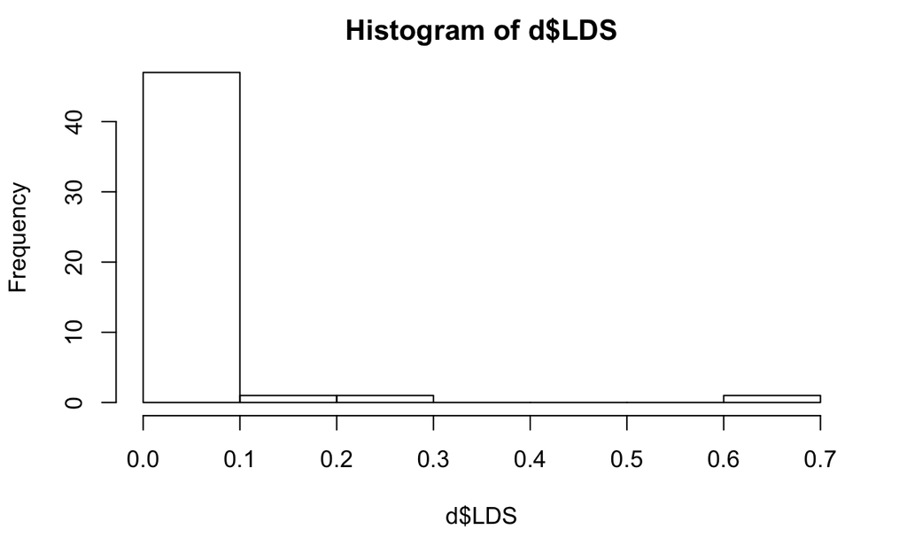

```r
hist(d$LDS)
```

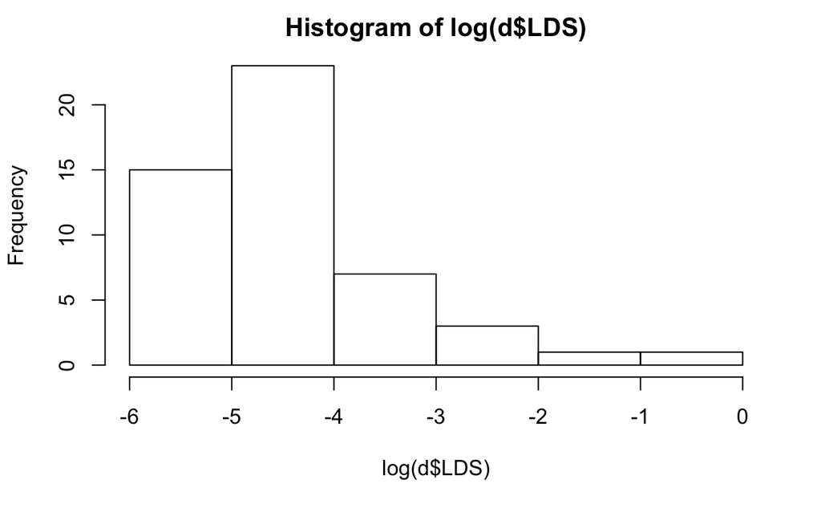

```r
hist(log(d$LDS))
```

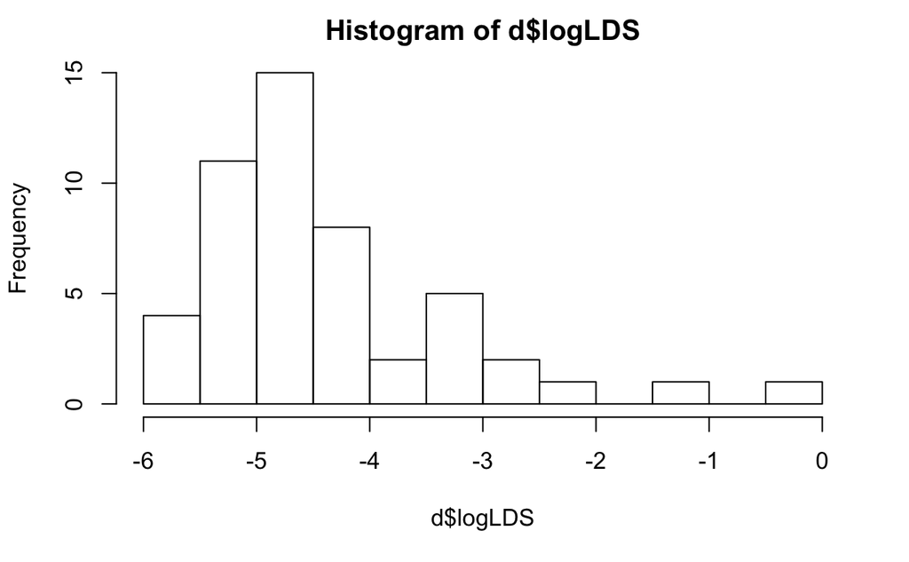

```r
d <- d %>%
  mutate(logLDS = log(LDS)) %>%
  mutate(logLDS.s = (logLDS - mean(logLDS))/sd(logLDS))

hist(d$logLDS, breaks = 9)
```

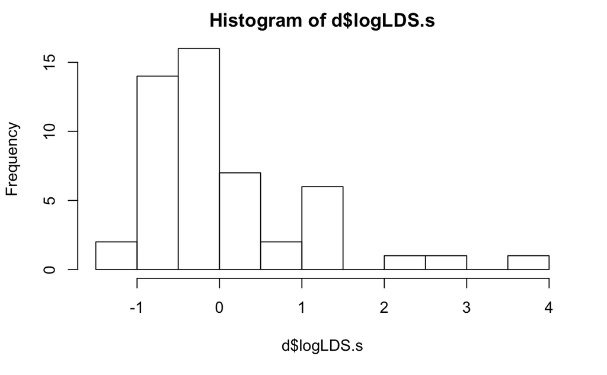

```r
hist(d$logLDS.s, breaks = 9)
```

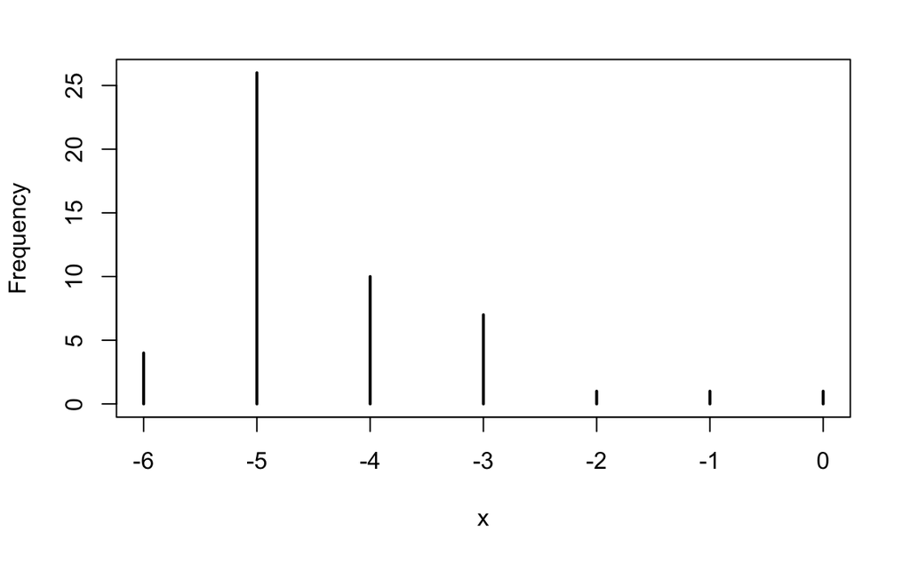

```r
simplehist(d$logLDS)
```

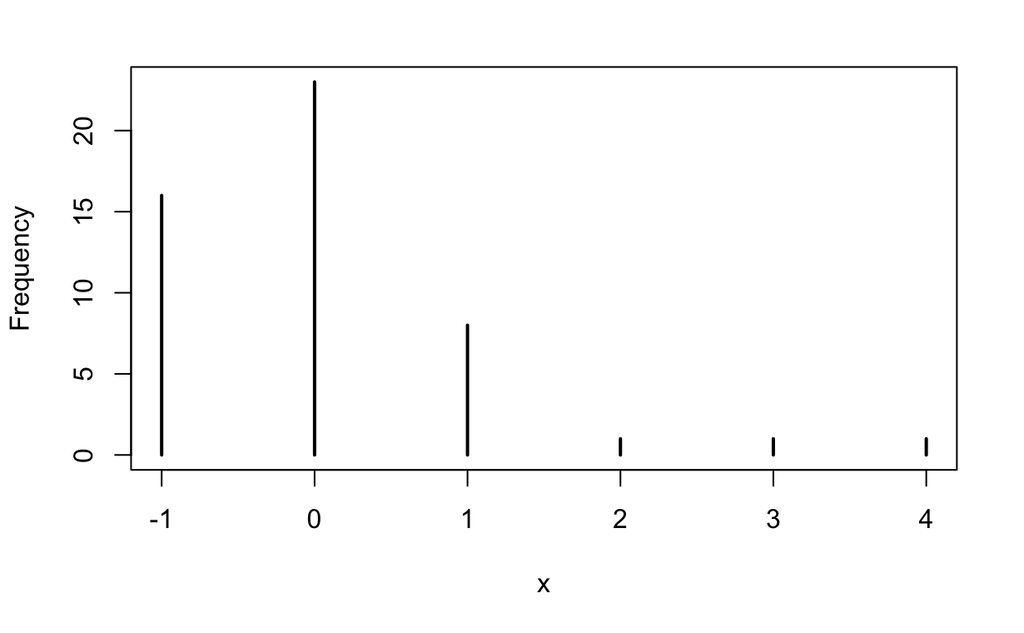

```r
simplehist(d$logLDS.s)
```

Now make a new model:

```r
library(rethinking)
detach("package:purrr")
names(d)
```

```
 [1] "Location"          "Loc"               "Population"
 [4] "MedianAgeMarriage" "Marriage"          "Marriage.SE"
 [7] "Divorce"           "Divorce.SE"        "WaffleHouses"
[10] "South"             "Slaves1860"        "Population1860"
[13] "PropSlaves1860"    "LDS"               "logLDS"
[16] "logLDS.s"
```

```r
m5M4 <- map(
  alist(
    Divorce ~ dnorm(mu, sigma),
    mu <- a + bR*Marriage + bA*MedianAgeMarriage + bL*logLDS.s,
    a ~ dnorm( 10 , 20 ) ,
    bR ~ dnorm( 0 , 10 ) ,
    bA ~ dnorm( 0 , 10 ) ,
    bL ~ dnorm(0, 10),
    sigma ~ dunif( 0 , 10 )
  ),
  data = d
)
precis(m5M4)
```

|  | Mean | StdDev | 5.5% | 94.5% |
| --- | --- | --- | --- | --- |
| a | 35.45 | 6.77 | 24.63 | 46.27 |
| bR | 0.05 | 0.08 | -0.08 | 0.19 |
| bA | -1.03 | 0.22 | -1.39 | -0.67 |
| bL | -0.62 | 0.29 | -1.08 | -0.15 |
| sigma | 1.38 | 0.14 | 1.16 | 1.60 |

### 5M5

From jmgirard: To address these two mechanisms, we need variables that would capture them. For the first mechanism, a variable corresponding to time spent exercising would be a reasonable start. For the second mechanism, a variable corresponding to frequency of eating out at restaurant would be a reasonable start. We could get even fancier and try to measure things like calories burned during exercise and calories ingested at restaurants. However, we would want to be careful not to introduce multicollinearity by adding highly correlated variables. So, I would propose the following multiple regression model:

$$\begin{align}
\mu_{i} = \alpha + \beta_{G}{G_i} + \beta_{E}E_{i} + \beta_{R}R_{i}
\end{align}$$

where $G$ represents the price of gasoline, $E$ represents one exercise-related variable, and $R$ represents one restaurant-related variable. One version of this model might use self-reported frequencies of exercise and eating out, and another version might use more rigorously measured calories burned through exercise and calories ingested from restaurants.

## Hard

```r
d <- read.table(
  "https://raw.githubusercontent.com/rmcelreath/rethinking/master/data/foxes.csv",
  header = TRUE,
  sep = ";")
d
```

| group | avgfood | groupsize | area | weight |
| --- | --- | --- | --- | --- |
| 1 | 0.37 | 2 | 1.09 | 5.02 |
| 1 | 0.37 | 2 | 1.09 | 2.84 |
| 2 | 0.53 | 2 | 2.05 | 5.33 |
| 2 | 0.53 | 2 | 2.05 | 6.07 |
| 3 | 0.49 | 2 | 2.12 | 5.85 |
| 3 | 0.49 | 2 | 2.12 | 3.25 |
| 4 | 0.45 | 2 | 1.29 | 4.53 |
| 4 | 0.45 | 2 | 1.29 | 4.09 |
| 5 | 0.74 | 3 | 3.78 | 6.13 |
| 5 | 0.74 | 3 | 3.78 | 5.59 |

[output cut: 106 more lines]

```r
summary(d)
```

```
     group          avgfood         groupsize          area           weight
 Min.   : 1.00   Min.   :0.3700   Min.   :2.000   Min.   :1.090   Min.   :1.920
 1st Qu.:11.75   1st Qu.:0.6600   1st Qu.:3.000   1st Qu.:2.590   1st Qu.:3.720
 Median :18.00   Median :0.7350   Median :4.000   Median :3.130   Median :4.420
 Mean   :17.21   Mean   :0.7517   Mean   :4.345   Mean   :3.169   Mean   :4.530
 3rd Qu.:24.00   3rd Qu.:0.8000   3rd Qu.:5.000   3rd Qu.:3.772   3rd Qu.:5.375
 Max.   :30.00   Max.   :1.2100   Max.   :8.000   Max.   :5.070   Max.   :7.550
```

### 5H1

```r
ma <- map(
  alist(
    weight ~ dnorm(mu, sigma),
    mu  <-a + bA * area,
    a ~ dnorm(5, 5),
    bA ~ dnorm(0, 5),
    sigma ~ dunif(0, 5)
  ),
  data = d
)

mg <- map(
  alist(
    weight ~ dnorm(mu, sigma),
    mu <- a + bG * groupsize,
    a ~ dnorm(5, 5),
    bG ~ dnorm(0, 5),
    sigma ~ dunif(0, 5)
  ),
  data = d
)

precis(ma)
```

|  | Mean | StdDev | 5.5% | 94.5% |
| --- | --- | --- | --- | --- |
| a | 4.45 | 0.39 | 3.83 | 5.08 |
| bA | 0.02 | 0.12 | -0.16 | 0.21 |
| sigma | 1.18 | 0.08 | 1.06 | 1.30 |

```r
precis(mg)
```

|  | Mean | StdDev | 5.5% | 94.5% |
| --- | --- | --- | --- | --- |
| a | 5.07 | 0.32 | 4.55 | 5.59 |
| bG | -0.12 | 0.07 | -0.24 | -0.01 |
| sigma | 1.16 | 0.08 | 1.04 | 1.29 |

```r
area.seq <- seq(from = min(d$area),
                to = max(d$area),
                length.out = 30)
mu <- link(ma, data = data.frame(area = area.seq))
```

```
[ 100 / 1000 ]
[ 200 / 1000 ]
[ 300 / 1000 ]
[ 400 / 1000 ]
[ 500 / 1000 ]
[ 600 / 1000 ]
[ 700 / 1000 ]
[ 800 / 1000 ]
[ 900 / 1000 ]
[ 1000 / 1000 ]
```

```r
mu.PI <- apply(mu, 2, PI)

# plot it:
plot(weight ~ area, data = d, col = rangi2)
abline(ma)
```

```
only using the first two of 3 regression coefficients
```

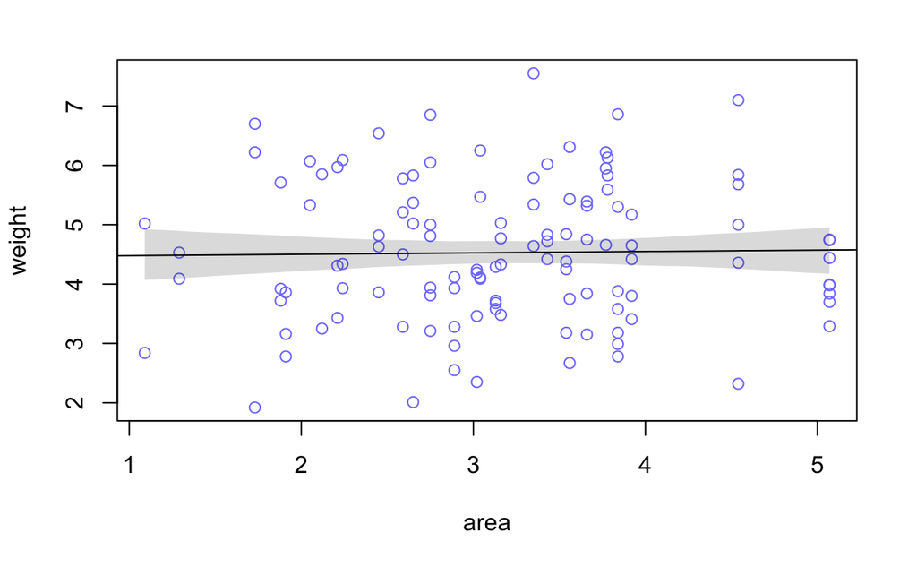

```r
shade(mu.PI, area.seq)
```

```r
gs.seq <- seq(from = min(d$groupsize),
              to = max(d$groupsize),
              length.out = 30)
mu <- link(mg, data = data.frame(groupsize = gs.seq))
```

```
[ 100 / 1000 ]
[ 200 / 1000 ]
[ 300 / 1000 ]
[ 400 / 1000 ]
[ 500 / 1000 ]
[ 600 / 1000 ]
[ 700 / 1000 ]
[ 800 / 1000 ]
[ 900 / 1000 ]
[ 1000 / 1000 ]
```

```r
mu.PI <- apply(mu, 2, PI)

# plot it
plot(weight ~ groupsize, data = d, col = rangi2)
abline(mg)
```

```
only using the first two of 3 regression coefficients
```

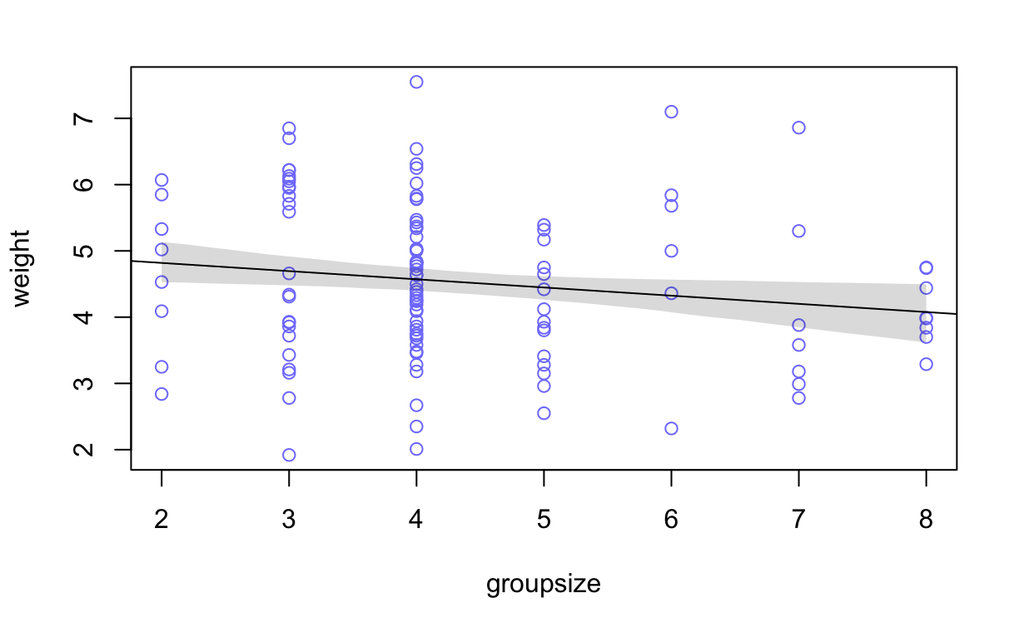

```r
shade(mu.PI, gs.seq)
```

### 5H2

```r
mag <- map(
  alist(
    weight ~ dnorm(mu, sigma),
    mu <- a + ba * area + bg * groupsize,
    a ~ dnorm(5, 5),
    ba ~ dnorm(0, 5),
    bg ~ dnorm(0, 5),
    sigma ~ dunif(0, 5)
  ),
  data = d
)

precis(mag)
```

|  | Mean | StdDev | 5.5% | 94.5% |
| --- | --- | --- | --- | --- |
| a | 4.45 | 0.37 | 3.86 | 5.05 |
| ba | 0.62 | 0.20 | 0.30 | 0.94 |
| bg | -0.43 | 0.12 | -0.62 | -0.24 |
| sigma | 1.12 | 0.07 | 1.00 | 1.24 |

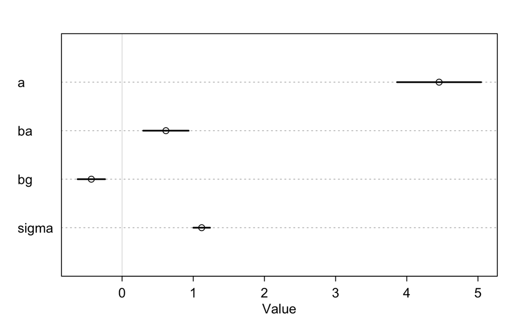

```r
plot(precis(mag))
```

```r
# counterfactual plot for territory area
G.avg <- mean(d$groupsize)
A.seq <- seq(from = 0, to = 6, length.out = 30)
pred.data <- data.frame(
  area = A.seq,
  groupsize = G.avg
)

# compute counterfactual mean area
mu <- link(mag, data = pred.data)
```

```
[ 100 / 1000 ]
[ 200 / 1000 ]
[ 300 / 1000 ]
[ 400 / 1000 ]
[ 500 / 1000 ]
[ 600 / 1000 ]
[ 700 / 1000 ]
[ 800 / 1000 ]
[ 900 / 1000 ]
[ 1000 / 1000 ]
```

```r
mu.mean <- apply(mu, 2, mean)
mu.PI <- apply(mu, 2, PI)

# simulat counterfactual area outcomes
A.sim <- sim(mag, data = pred.data, n = 1e4)
```

```
[ 1000 / 10000 ]
[ 2000 / 10000 ]
[ 3000 / 10000 ]
[ 4000 / 10000 ]
[ 5000 / 10000 ]
[ 6000 / 10000 ]
[ 7000 / 10000 ]
[ 8000 / 10000 ]
[ 9000 / 10000 ]
[ 10000 / 10000 ]
```

```r
A.PI <- apply(A.sim, 2, PI)

# display redictions, hiding raw data with type = "n"
plot(weight ~ area, data = d, type = "n")
mtext("groupsize = 4.345")
```

```r
lines(A.seq, mu.mean)
shade(mu.PI, A.seq)
```

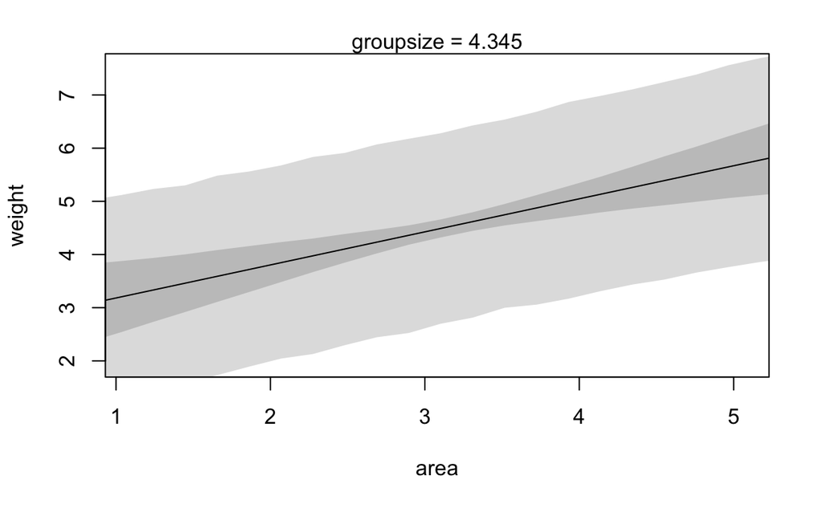

```r
shade(A.PI, A.seq)
```

```r
# counterfacutal plot for group size
G.seq <- seq(from = 1, to = 9, length.out = 30)
A.avg <- mean(d$area)
pred.data <- data.frame(
  area = A.avg,
  groupsize = G.seq
)

# compute counterfactual mean groupsize
mu <- link(mag, data = pred.data)
```

```
[ 100 / 1000 ]
[ 200 / 1000 ]
[ 300 / 1000 ]
[ 400 / 1000 ]
[ 500 / 1000 ]
[ 600 / 1000 ]
[ 700 / 1000 ]
[ 800 / 1000 ]
[ 900 / 1000 ]
[ 1000 / 1000 ]
```

```r
mu.mean <- apply(mu, 2, mean)
mu.PI <- apply(mu, 2, PI)

# simulate counterfactual groupsize outcomes
G.sim <- sim(mag, data = pred.data, n = 1e4)
```

```
[ 1000 / 10000 ]
[ 2000 / 10000 ]
[ 3000 / 10000 ]
[ 4000 / 10000 ]
[ 5000 / 10000 ]
[ 6000 / 10000 ]
[ 7000 / 10000 ]
[ 8000 / 10000 ]
[ 9000 / 10000 ]
[ 10000 / 10000 ]
```

```r
G.PI <- apply(G.sim, 2, PI)

# display predictions, hiding raw data with type="n"
plot(weight ~ groupsize, data = d, type="n")
mtext("area = 3.17")
```

```r
lines(G.seq, mu.mean)
shade(mu.PI, G.seq)
```

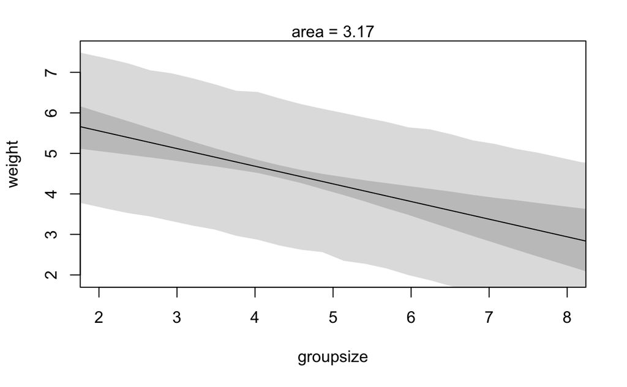

```r
shade(G.PI, G.seq)
```

### 5H3

```r
m5h3_2 <- map(
  alist(
    weight ~ dnorm(mu, sigma),
    mu <- a + bf * avgfood + bg * groupsize,
    a ~ dnorm(5, 5),
    bf ~ dnorm(0, 5),
    bg ~ dnorm(0, 5),
    sigma ~ dunif(0, 5)
  ),
  data = d
)

precis(m5h3_2)
```

|  | Mean | StdDev | 5.5% | 94.5% |
| --- | --- | --- | --- | --- |
| a | 4.18 | 0.43 | 3.50 | 4.86 |
| bf | 3.60 | 1.18 | 1.72 | 5.48 |
| bg | -0.54 | 0.15 | -0.79 | -0.30 |
| sigma | 1.12 | 0.07 | 1.00 | 1.23 |

```r
NA
```

```r
m5h3_3 <- map(
  alist(
    weight ~ dnorm(mu, sigma),
    mu <- a + bf * avgfood + bg * groupsize + ba * area,
    a ~ dnorm(5, 5),
    bf ~ dnorm(0, 5),
    bg ~ dnorm(0, 5),
    ba ~ dnorm(0, 5),
    sigma ~ dunif(0, 5)
  ),
  data = d
)

precis(m5h3_3)
```

|  | Mean | StdDev | 5.5% | 94.5% |
| --- | --- | --- | --- | --- |
| a | 4.10 | 0.42 | 3.42 | 4.78 |
| bf | 2.30 | 1.39 | 0.08 | 4.53 |
| bg | -0.59 | 0.15 | -0.84 | -0.35 |
| ba | 0.40 | 0.24 | 0.02 | 0.78 |
| sigma | 1.10 | 0.07 | 0.99 | 1.22 |